Brain, Behavior, and Immunity 98 (2021) 59–73

Available online 5 August 2021

0889-1591/© 2021 Elsevier Inc. All rights reserved.

Neurogenic and anti-inflammatory effects of probiotics in Parkinson’s

disease: A systematic review of preclinical and clinical evidence

Valentina Leta <sup>a</sup><sup>,</sup><sup>b</sup><sup>,</sup>**, K. Ray Chaudhuri <sup>a</sup><sup>,</sup><sup>b</sup>, Oliver Milner <sup>a</sup>, Guy Chung-Faye <sup>c</sup>, Vinod Metta <sup>b</sup>,

Carmine M. Pariante <sup>d</sup>, Alessandra Borsini <sup>e</sup><sup>,</sup>*

a *King**’**s College London, Department of Neurosciences, Institute of Psychiatry, Psychology* *&* *Neuroscience, De Crespigny Park, London SE5 8AF, UK*

b *Parkinson**’**s Foundation Centre of Excellence, King**’**s College Hospital, Denmark Hill, London SE5 9RS, UK*

c *Department of Gastroenterology, King**’**s College Hospital, London, UK*

d *Department of Psychological Medicine, Institute of Psychiatry, Psychology and Neuroscience, Kings College London, UK*

e *National Institute for Health Research (NIHR), Mental Health Biomedical Research Centre at South London and Maudsley NHS Foundation Trust and King**’**s College,*

*London, UK*

A R T I C L E I N F O

*Keywords:*

Probiotics

Parkinson’s disease

Neurodegeneration

Inflammation

Metabolism

Motor symptoms

Non-motor symptoms

A B S T R A C T

There is increasing evidence highlighting the potential role of the gut-brain axis in the pathogenesis of Par-

kinson’s disease (PD) and on the use of probiotics as a therapeutic strategy for this neurodegenerative disorder.

While several studies have been published on the topic in recent years, there is still a lack of a comprehensive

understanding of the effects of probiotics in PD and their possible underlying mechanisms. Through this sys-

tematic review, we collected a total of 17 articles, consisting of preclinical and clinical models of PD investigating

the effect of probiotics on (1) energy metabolism, (2) inflammation and oxidative stress, (3) neurodegeneration,

as well as (4) motor and (5) non-motor function. Articles were obtained from PubMed/Medline, Scopus, Web of

Science and Embase databases. Findings from preclinical studies suggest that treatment with probiotics increases

glucose metabolism (increased secretion of glucagon-like peptide-1), reduces peripheral and central inflamma-

tion (reduced interleukin-6 and tumor necrosis factor-α (TNF-α)), reduces peripheral and central oxidative stress

(reduced peripheral superoxide anion levels and increased central antioxidant glutathione levels), decreases

neurodegeneration (increased numbers of tyrosine hydroxylase dopaminergic neurons and levels of brain-

derived neurotrophic factor), increases motor function (increased motor agility) and non-motor function

(decreased memory deficits). Similarly, findings from clinical studies suggest that probiotics increase glucose

metabolism (reduced insulin resistance), reduce peripheral inflammation (reduced peripheral TNF-α expression

and C-reactive protein levels), and increase motor and non-motor function (decreased overall PD symptom-

atology and constipation); however, findings on oxidative stress were inconclusive across studies. Overall, this

review is the first one to systematically report evidence for the putative beneficial effects of probiotics on mo-

lecular and cellular mechanisms, as well as behavioural phenotypes, in either preclinical or clinical studies in PD.

However, additional and more robust studies are still needed to confirm these outcomes, and should aim to focus

more on bench-to-bedside approaches, in order to address the existing gaps between preclinical and clinical

findings in this field.

**1. Introduction**

Over the last decade, there has been increasing attention on the role

of the gut microbiota in human health and diseases. The gut microbiota

consists of a community of bacteria, viruses, protozoa, and fungi that

dwell in the human gastrointestinal tract and intimately communicate

*Abbreviations:* BDNF, brain-derived neurotrophic factor; CRP, C-reactive protein; GFAP, glial fibrillary acid protein; GLP-1, glucagon-like peptide 1; GSH,

glutathione; Iba1, ionized calcium-binding adaptor molecule 1; IL-6, interleukin 6; PPARγ, peroxisome proliferator-activated receptor gamma; SN, substantia nigra;

TH+, tyrosine hydroxylase positive; TNF-α, tumour necrosis factor-alpha.

* Corresponding author at: The Maurice Wohl Clinical Neuroscience Institute G.33.71, Cutcombe Road, London SE5 9RT, UK.

** Co-corresponding author at: The Maurice Wohl Clinical Neuroscience Institute, King’s College London, Cutcombe Road, London SE5 9RT, UK.

*E-mail addresses:* valentina.1.leta@kcl.ac.uk (V. Leta), alessandra.borsini@kcl.ac.uk (A. Borsini).

[figure not shown]

Contents lists available at ScienceDirect

Brain Behavior and Immunity

journal homepage: www.elsevier.com/locate/ybrbi

[figure not shown]

https://doi.org/10.1016/j.bbi.2021.07.026

Received 28 February 2021; Received in revised form 26 July 2021; Accepted 31 July 2021

*Brain Behavior and Immunity 98 (2021) 59–73*

60

with the human host, modulating intestinal barrier function, meta-

bolism, and immune as well as nervous system activity (Hollister et al.,

2014). The gut microbiota represents, indeed, one of the main charac-

ters of the gut-brain axis, a bidirectional network between the gastro-

intestinal tract and the central nervous system (CNS), and is able to

regulate multiple biological mechanisms and, ultimately, brain activity.

Different are the pathways of communication between the gut and the

CNS which include the autonomic nervous system (mainly the enteric

nervous system and the vagus nerve), the neuroendocrine system, the

hypothalamic-pituitaryadrenal axis, metabolic pathways, and the im-

mune system (Morais et al., 2021).

As the gastrointestinal tract represents a gateway to the environ-

ment, the cross-talk between the human host and the gut microbiota

becomes particularly relevant in diseases where environmental factors,

including diet and exposure to toxins, seem to contribute to or protect

against the development of specific pathological conditions, including

idiopathic Parkinson’s disease (PD) (Klingelhoefer and Reichmann,

2015). PD is a neurodegenerative condition commonly regarded as a

movement disorder where motor dysfunction, including tremor, rigid-

ity, and bradykinesia, mainly result from loss of dopaminergic neurons

in the substantia nigra; however, it is well known now that a variety of

non-motor features, including symptoms of depression and anxiety,

cognitive impairments, pain and constipation, can also occur across all

stages of PD (Kalia and Lang, 2015; Schapira et al., 2017).

Several studies have shown alterations in the gut microbiota of pa-

tients with PD when compared with healthy controls (Heintz-Buschart

et al., 2018; Scheperjans et al., 2015; Wallen et al., 2020) and associa-

tions between faecal levels of specific bacteria and motor and non-motor

features, such as tremor, postural instability and constipation (Sche-

perjans et al., 2015). Although results of these studies are extremely

heterogeneous, mainly due to differences in study methodology and

presence of confounding factors, including diet, geographical back-

ground and medication (Boertien et al., 2019), two recent meta-analyses

reported a pro-inflammatory gut microbiota in PD characterised by

depletion of short chain fatty acids (SCFAs) producing bacteria (Nishi-

waki et al., 2020; Romano et al., 2020). SCFAs are metabolites deriving

from intestinal microbial fermentation and exert multiple beneficial

effects on human health, being able to decrease intestinal and systemic

inflammation and promote normal neuronal as well as microglia

maturation (Keshavarzian et al., 2020). Notably, both the level of SCFAs

producing bacteria and faecal levels of these metabolites are reduced in

patients with PD when compared with healthy controls (Unger et al.,

2016; Wallen et al., 2020).

According to recent preclinical and clinical evidence, a new and

debated gut-originating pathogenesis model of PD has been postulated,

whereby, in some susceptible individuals, PD might be initiated by the

ingestion of inflammatory triggers, such as pesticides or pollutants,

which can alter the gut microbiota, increase intestinal inflammation,

and lead to misfolded α-synuclein (one of the pathological hallmarks of

PD) (Metta et al., 2021; Leta et al., 2021). The latter could then access

the CNS via the gut-brain axis, ultimately stimulating central inflam-

mation, and neurodegeneration (Houser and Tansey, 2017). Indeed, on

one side α-synuclein peptides may act as antigenic epitopes and drive

immune response in PD (Sulzer et al., 2017); on the other side, proin-

flammatory immune activity can increase levels of α-synuclein both in

the gut and brain (Griffin et al., 2006; Kelly et al., 2014) and its ag-

gregation (Shults, 2006). This positive inflammatory loop can eventu-

ally contribute to neuronal death (Rocha et al., 2015).

The identification of a proinflammatory alteration of the gut

microbiota in PD, and its potential role in the pathogenesis of this

neurogenerative disorder, has driven the interest in investigating the use

of gut microbiota-modulating interventions, such as probiotics, as

possible novel therapeutic strategies for PD. Probiotics are defined by

the World Health Organization as “live microorganisms which when

administered in adequate amounts confer a health benefit on the host”

(https://www.who.int/foodsafety/probiotic_guidelines.pdf),

and

evidence supports their beneficial effects on a variety of human diseases,

including metabolic and gastrointestinal disorders (Markowiak and

´Sli˙zewska, 2017), as well as neurological and neuropsychiatric condi-

tions (Bermúdez-Humar´an et al., 2019). Probiotics can exert their

beneficial effects via several mechanisms of action, including: 1) colo-

nisation and normalisation of a perturbed intestinal microbial commu-

nity; 2) improvement of intestinal barrier function; and 3) activation of

enzymatic activities and subsequent production of metabolites that

positively regulate peripheral and central energy metabolism and

inflammation, as well as neurogenesis, neurotransmission and, ulti-

mately, behaviour (Barcelo et al., 2000).

Existing literature has demonstrated that probiotics can affect brain

activity by reducing neuroinflammation and, consequently, increasing

neurogenesis. In particular, preclinical models of rodents have shown

that probiotics can decrease peripheral levels of inflammatory cyto-

kines, such as interleukin-1beta (IL-1β) and IL-6 (Mohammadi et al.,

2019; Xin et al., 2020), and ultimately prevent neuroinflammation

(Shahbazi et al., 2020). In fact, these peripheral cytokines are often able

to cross the blood-brain barrier and access brain regions relevant for

neurogenesis, especially the hippocampus, where they can exert detri-

mental effects on cell viability, proliferation, and differentiation (Borsini

et al., 2017; Borsini et al., 2018; Borsini et al., 2020). Considering that a

proinflammatory status and neurodegeneration are well-known char-

acteristics of the PD pathology (Lim et al., 2018), clinical intervention

with probiotics seems a promising therapeutic approach for this

condition.

While evidence like this has suggested a beneficial role of probiotics

in PD, there still is a lack of a comprehensive understanding concerning

how they exert their properties. Therefore, in this work, we aimed to

systematically review all available findings generated from both *pre-*

*clinical* and *clinical* studies investigating the role of probiotics on

candidate mechanisms underlying the PD pathology, and in particular:

(1) energy metabolism, (2) inflammation and oxidative stress, (3) neu-

rodegeneration, (4) motor and (5) non-motor function. Ultimately, this

review will provide a better understanding of the existing gaps between

preclinical and clinical research on the topic and possibly provide future

research directions.

**2. Methods**

The review follows the Preferred Reporting Items for Systematic

Reviews and Meta-Analyses (PRISMA) statement (Liberati et al., 2009;

Moher et al., 2009). We searched for both preclinical and clinical articles

published until January 2021 in the following databases: PubMed/

Medline, Scopus, Web of Science and Embase, and used the following

search terms: Parkinson’s disease AND probiotics AND ((metabolism)

OR (inflammation) OR (neurodegeneration OR neurogenesis) OR

(motor OR parkinsonism) OR (non-motor OR behaviour OR cognition

OR anxiety OR depression OR pain OR constipation)). Two independent

authors (VL and OM) conducted the literature search, the initial analysis

of titles and abstracts, and retrieved full-text articles for detailed review.

Included articles were original research studies published or in-press

and written in English. For studies conducted on animals, inclusion

required the use of established animal models of PD (Konnova and

Swanberg, 2018). For human studies, inclusion required the diagnosis of

PD according to Movement Disorder Society (Postuma et al., 2015) or

UK Parkinson’s Disease Society Brain Bank diagnostic criteria (Hughes

et al., 1992). A total of 251 articles were retrieved (Fig. 1), of which only

17 fit the eligibility criteria of our search, after exclusion of duplicates

and non-relevant papers. Out of the 17 articles retained, 12 were pre-

clinical studies and 5 were clinical studies. Risk of bias was assessed

using the SYRCLE guidelines (Hooijmans et al., 2014) or the Rob 2 tool

(Sterne et al., 2019), respectively for studies conducted in animals and

humans. The overall risk of bias was low (Supplementary Materials).

*V. Leta et al.*

*Brain Behavior and Immunity 98 (2021) 59–73*

61

**3. Results**

*3.1. Preclinical studies*

A total of 12 preclinical studies were identified, 10 *in vivo* (Alipour

Nosrani et al., 2020; Dwyer et al., 2021; Goya et al., 2020; Hsieh et al.,

2020; Liao et al., 2020; Marsova et al., 2020; Perez Vis˜nuk et al., 2020;

Srivastav et al., 2019; Sun et al., 2020; Xie and Prasad, 2020)*,* 1 both *in*

*vitro* and *in vivo* (Castelli et al., 2020)*,* and 1 *ex vivo* (Magistrelli et al.,

2019) (Table 1).

*3.1.1. Energy metabolism*

Five preclinical studies, 4 *in vivo* (Alipour Nosrani et al., 2020; Goya

et al., 2020; Liao et al., 2020; Sun et al., 2020) and 1 both *in vitro* and *in*

*vivo* (Castelli et al., 2020), investigated the effects of probiotics on en-

ergy metabolism in PD (Table 1), and, overall, found that probiotics may

prevent the decrease in glucose metabolism in PD models.

In particular, 1–16 day-treatment with *Bacillus subtilis PXN21*

increased the expression of ceramide synthase (lagr-1/ceramide syn-

thase 1 (CERS1)) and acid sphingomyelinase (acid sphingomyelinase 3

(asm-3)/sphingomyelin phosphodiesterase 1 (SMPD1)) genes, all

involved in the metabolism of the sphingolipids, in a *C. elegans* model of

synucleinopathy (overexpression of α-synuclein) (Goya et al., 2020).

Similarly, 2-week treatment with a combination of probiotics belonging

to the *Firmicutes* or *Actinobacteria* phylum prevented midbrain increase

in malondialdehyde (MDA), a metabolite resulting from lipid peroxi-

dation, in a 6-hydroxydopamine (6-OHDA) model of PD (Alipour Nos-

rani et al., 2020).

Four-week treatment with *Clostridium butyricum* WZMC1016 pre-

vented the decrease in colonic levels of SCFAs receptors (G-protein-

coupled receptor (GPR41/43)) and hormone glucagon-like peptide 1

(GLP-1), as well as cerebral expression of GLP-1 receptors, known to

regulate glucose metabolism, in a 1-methyl-4-phenyl-1,2,3,6-tetrahy-

dropyridine (MPTP) model of PD (Sun et al., 2020). In contrast, 4-

week treatment with *Lactobacillus plantarum PS128* did not prevent the

decrease in SCFAs faecal levels in an MPTP model of PD (Liao et al.,

2020).

Five-week administration of a mixture of probiotics belonging to the

*Firmicutes* or *Actinobacteria* phylum prevented the decrease in protein

levels of peroxisome proliferator-activated receptor-gamma (PPAR-γ), a

transcription factor activated by GLP-1 and involved in lipid storage and

glucose metabolism, in the substantia nigra of a 6-OHDA model of PD

(Castelli et al., 2020). In the same study, 2-hour treatment with the same

mixture of probiotics prevented the decrease in PPAR-γ protein levels,

this time in an *in vitro* 6-OHDA model of PD using dopaminergic-like SH-

SY5Y neuro-blastoma cells (Castelli et al., 2020).

In conclusion, evidence suggests that probiotics treatment can

stimulate the GLP-1 pathway leading to activation of PPAR-γ, increase

sphingolipid metabolism, and reduce lipid peroxidation; however, there

is inconclusive data on their ability to increase intestinal levels of SCFAs.

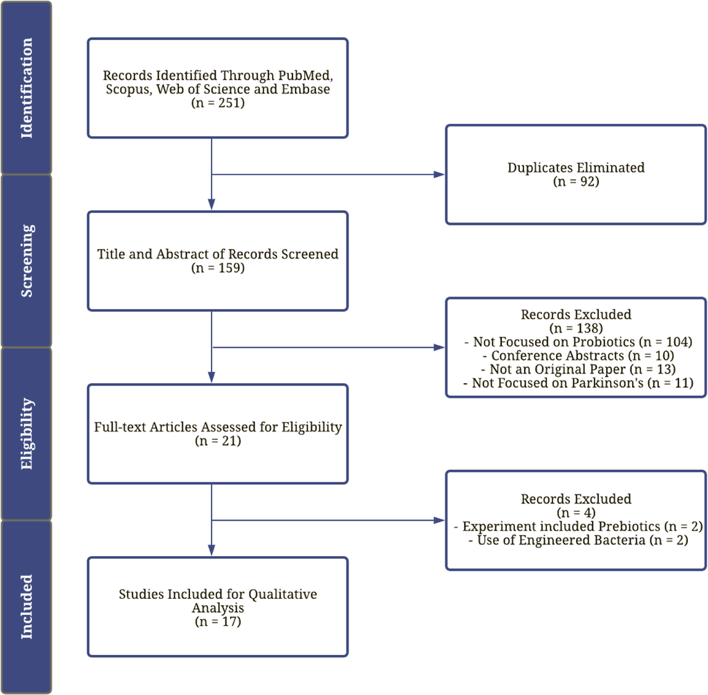

**Fig. 1.** Flow diagram of the search and selection process. Seventeen studies met the eligibility criteria and investigated the effects of probiotics on either energy

metabolism, peripheral and central inflammation, oxidative stress, neurodegeneration, motor or non-motor function or a combination of them in Parkinson’s disease

(12 preclinical studies and 5 clinical studies).

*V. Leta et al.*

*Brain Behavior and Immunity 98 (2021) 59–73*

62

**Table 1**

Effects of probiotics on Parkinson’s disease in preclinical studies (*in vitro, ex vivo* and *in vivo* studies).

Strains of Probiotics

Concentration

Duration

intervention

Model

Study design

Energy metabolism-

related outcomes

Inflammation- and

Oxidative stress-

related outcomes

Neurodegeneration-

related outcomes

Motor- and Non-

Motor-related

outcomes

**Study**

*Lactobacillus acidophilus* and

*Bifidobacterium Bifidum* and

*Lactobacillus reuteri* and

*Lactobacillus fermentum*

Each strain

administered 2 ×

109 CFU/day

2 weeks

Male Wistar rats,

Age not reported

(weighing 200–250

g), treated with 6-

OHDA after

intervention

Pre-treatment &

Treatment with

Probiotics vs

Sham

× increased MDA

midbrain levels

(spectrophotometry)

× increased number of

injured neurons in the

SN (IHC)

× increased number

of contralateral

rotations

(Apomorphine-

induced behavioural

assessment in

cylindrical clear

chamber)

× increased escape

latency (Morris water

maze)

× decreased time

spent in the target

quadrant (probe trial)

Alipour

Nosrani

et al., 2020

*Streptococcus thermophilus* and

*Bifidobacterium longum* and

*Bifidobacterium breve* and

*Bifidobacterium infantis* and

*Lactobacillus acidophilus* and

*Lactobacillus plantarum* and

*Lactobacillus paracasei* and

*Lactobacillus delbrueckii*

subsp. *Bulgaricus* and

*Lactobacillus brevis*

0.1 mg/ml

2 h

Dopaminergic-like

SH-SY5Y neuro-

blastoma cells,

treated with 6-

OHDA before

intervention

Treatment with

Probiotic vs

Sham

× decreased PPAR-γ

(WB)

× increased 4-HNE

(WB)

× decreased cell

viability (MTS assay)

× decreased m-BDNF,

p-TrkB, p-ERK5, p-

CREB, PI3K, p-AKT,

and PSD95 (WB)

× increased pro-BDNF,

p-JNK, p-ERK1,2, and

p75 (WB)

Castelli

et al., 2020

5.4 billion

bacteria/day

5 weeks

Male C57BL/6 mice,

9 weeks old (weight

not reported),

treated with 6-

OHDA after start

intervention

Pre-treatment &

Treatment with

Probiotic vs

Sham

× decreased PPAR-γ

levels and nuclear

localization in SN (IF)

(WB)

× increased Iba1-

positive glial cells

in the SN (IF)

× increased GFAP

levels in the SN (IF)

× decreased p-

NRF2, HO-1 in SN

and striatum (WB)

× increased NFκB

in SN and striatum

(WB)

× decreased TH-

positive fibres in

striatum (IHC)

× decreased TH-

positive cells in SN

(IHC)

× decreased DAT-

positive cells in SN (IF)

× decreased BDNF, p-

TrkB in striatum and SN

(WB)

× increased apoptotic

nuclei in SN (IF)

× decreased

contralateral paw use

(cylinder test)

× increased biased

swings (elevated

body swing test)

× increased

contralateral

rotations/min

(Apomorphine test)

*Bacillus subtilis PXN21, 168,*

*JH642, NCIB 3610*

1–16 days

*C. elegans* (NL5901)

expressing α-*syn*-

YFP before

intervention

Diet with

*Bacillus subtilis*

*PXN21, 168,*

*JH642, NCIB*

*3610* vs Diet

with *Escherichia*

*coli OP50*

↑ expression lipid

metabolism genes lagr-

1 and asm-3 (RNA

sequencing)

↓ expression of lipid

metabolism gene sptl-3

(RNA sequencing)

↑ expression of

immune system

genes

↑ expression of

redox processes

genes

↓ α-syn aggregates

formation (IF)

↑ α-syn aggregates

clearance (IF)

↑ α-syn levels (qRT-

PCR, WB)

↑ submonomeric forms

of α-syn (IB)

↑ locomotion fitness

(thrashing assay)

Goya et al.,

2020

*Lactobacillus plantarum PS128*

109 CFU in 200 μL

saline daily

4 weeks

Male C57BL/6J, 6

weeks old, mice

(weighing 20 – 22

g), treated with

MPTP after

intervention

Pre-treatment

with Probiotics

vs Sham

= SCFA faecal levels

(GC–MS analysis)

× increased serum

corticosterone

levels

× increased GFAP

and Iba1 levels in

the striatum (WB)

× increased TNF-α,

× decreased DA,

DOPAC, HVA, NE and

MHPG levels in

striatum (HPLC)

× decreased TH-

positive neurons in the

SN and striatum (IF and

× increased Inversion

time (pole test)

× increased total

descent time (pole

test)

× increased total

walking time

Liao et al.,

2020

(*continued on next page*)

*V. Leta et al.*

*Brain Behavior and Immunity 98 (2021) 59–73*

63

**Table 1** (*continued*)

Strains of Probiotics

Concentration

Duration

intervention

Model

Study design

Energy metabolism-

related outcomes

Inflammation- and

Oxidative stress-

related outcomes

Neurodegeneration-

related outcomes

Motor- and Non-

Motor-related

outcomes

**Study**

IL-1β and IL-6 levels

in the striatum and

midbrain (ELISA)

× decreased SOD,

GSH, catalase, GPx

levels in the

striatum

× decreased SOD,

GSH, catalase,

levels in the

midbrain

WB)

× decreased m-BDNF

and NGF levels in the

striatum (WB)

(narrow-beam test)

× decreased total

retention time

(rotarod test)

*Clostridium butyricum*

*WZMC1016*

5 × 108 CFU/0.2

mL/day

4 weeks

Male C57BL/6 mice,

6–8 weeks

(weighing 18–22 g),

treated with MPTP

before intervention

Treatment with

Probiotics vs

Sham

× decreased colonic

GLP-1 levels (IF)

× decreased GPR41 and

GPR43 colonic levels

(IHC and WB)

× decreased GLP-1R

brain levels (IHC and

WB)

× decreased TH-

positive neurons in the

SN (IHC)

× decreased synapsin I

in the SN (IHC and WB)

× increased Time to

complete (pole test)

× increased Time to

complete and number

of foot errors (beam

walking test)

× increased

Immobility time

(forced swimming

test)

× decreased crossing

number (open field

test)

Sun et al.,

2020

*Lactobacillus plantarum CRL*

*2130* and/or *Streptococcus*

*thermophilus CRL 807* and/or

*Streptococcus thermophilus*

*CRL 808*

100 mL of the

bacterial

suspension (8 ±

2x108 CFU/mL of

each strain)

individually or as a

mixture daily

3 weeks

Male C57BL/6 mice,

8 weeks old

(weighing 20–30 g),

treated with MPTP

after start

intervention

Pre-treatment &

Treatment with

Probiotics vs

Sham

× increased IL-6,

and TNF-a serum

levels (cytometric

bead array)

× decreased IL-10

serum levels

(cytometric bead

array)

= MCP-1 serum

levels (cytometric

bead array)

× increased TNF-a

brain levels

(cytometric bead

array)

× decreased TH-

positive neurons in the

SNpc (IHC)

× increased time to

completion (pole test,

transversal beam test,

Nasal bridge adhesive

removal test)

Perez

Vis˜nuk

et al., 2020

*Lactobacillus rhamnosus GG*

(LGG) and *Bifidobacterium*

*animalis lactis (BB12)* and

*Lactobacillus acidophilus*

*(LA5)*

~2x106 CFU/day

4 weeks

Male C57BL/6 mice,

7 weeks old (weight

not reported),

treated with MPTP

after intervention

Pre-treatment

with Probiotics

vs Sham

× increased GFAP

positive glial cells

in the SNpc (IHC)

× increased cell

body size and

processes thickness

of GFAP positive

glial cells in the

SNpc (IHC)

× increased Iba-1-

positive glial cells

in the SNpc (IHC)

× increased

processes thickness

× decreased TH-

positive neurons and

fibres in the SN and

striatum (IHC)

× decreased DA levels

in the striatum (HPLC)

× increased DA

turnover ratio in the

striatum (HPLC)

× decreased BDNF and

GDNF levels in the

brain (WB)

× decreased CREB

levels in the brain (WB)

× decreased stride

length of forelimb

and hindlimb (stride

length test)

× decreased rears for

3 mins (cylinder test)

× increased time

(beam transverse test)

× increased errors per

step (challenge beam

test)

Srivastav

et al., 2019

(*continued on next page*)

*V. Leta et al.*

*Brain Behavior and Immunity 98 (2021) 59–73*

64

**Table 1** (*continued*)

Strains of Probiotics

Concentration

Duration

intervention

Model

Study design

Energy metabolism-

related outcomes

Inflammation- and

Oxidative stress-

related outcomes

Neurodegeneration-

related outcomes

Motor- and Non-

Motor-related

outcomes

**Study**

of Iba-1-positive

glial cells in the

SNpc

Male C57BL/6 mice,

7 weeks old (weight

not reported),

treated with

Rotenone after

intervention

Pre-treatment

with Probiotics

vs Sham

× increased GFAP

positive glial cells

in the SNpc (IHC)

× increased cell

body size and

processes thickness

of GFAP positive

glial cells in the

SNpc (IHC)

× increased Iba-1-

positive glial cells

in the SNpc (IHC)

× increased cell

body size and

processes thickness

of Iba-1-positive

glial cells in the

*S*Npc

× decreased TH-

positive neurons and

fibres in the SN and

striatum (IHC)

× decreased DA levels

in the striatum (HPLC)

× increased DA

turnover ratio in the

striatum (HPLC)

× decreased BDNF and

GDNF levels in the

brain (WB)

× decreased stride

length of forelimb

and hindlimb (stride

length test)

× decreased rears for

3 mins (cylinder test)

× increased time

(beam transverse test)

× increased errors per

step (challenge beam

test)

*Bifidobacterium bifidum* and

*Bifidobacterium longum* and

*Lactobacillus rhamnosis* and

*Lactobacillus rhamnosus GG*

and *Lactobacillus plantarum*

*LP28* and *Lactococcus lactis*

subsp. *Lactis)*

1010 CFU/day

16 weeks

Male MitoPark

PD mouse

model, 8 weeks

old (weight not

reported)

Treatment with

Probiotics vs Sham

↑ TH-positive neurons

and fibres in the SNpc

(IHC)

↓ time to

completion

(beam

walking)

↑ latency to

fail

(rotaroad)

↑ Walking

speed (gait

analysis)

↑ step

length (gait

analysis)

↑ stride

length (gait

analysis)

↓ step width

(gait

analysis)

↓ stance

phase time

(gait

analysis)

↓ swing

phase time

(gait

analysis)

Hsieh et al., 2020

*Lactobacillus fermentum U-21*

108 CFU

Twice a week

for 3 weeks

(after each

Male C57BL/6J, 6

weeks old, mice

(weight not

reported), treated

Treatment with

Probiotics vs

Sham

× decreased TH-

positive neurons in the

SNpc (IHC)

× decreased highest

relative duration of

descent from the pole

(pole test)

Marsova

et al., 2020

(*continued on next page*)

*V. Leta et al.*

*Brain Behavior and Immunity 98 (2021) 59–73*

65

**Table 1** (*continued*)

Strains of Probiotics

Concentration

Duration

intervention

Model

Study design

Energy metabolism-

related outcomes

Inflammation- and

Oxidative stress-

related outcomes

Neurodegeneration-

related outcomes

Motor- and Non-

Motor-related

outcomes

**Study**

paraquat

injection)

with Paraquat

before intervention

*Lacticaseibacillus rhamnosus*

*HA-114*

109 CFU/ml

initially then and

108 CFU/ml from

day 5 onwards.

6 weeks

Male Sprague

Dawley rats, 3–4

months old

(weighing 450 g),

treated with 6-

OHDA before

intervention

Treatment with

Probiotics vs

Sham

= TH-positive neurons

in the SNpc (IHC)

× decreased novelty

place preference ratio

(place recognition

task)

= Novelty object

preference ratio

(object recognition

task)

= Time spent in open

arms (Elevated Plus

Maze)

Xie and

Prasad,

2020

*Lactobacillus plantarum* and

*Lactobacillus delbrueckii*

subsp. And *Bulgaricus,*

*Lactobacillus paracasei,* and

*Lactobacillus acidophilus* and

*Bifidobacterium breve* and

*Bifidobacterium longum* and

*Bifidobacterium infantis* and

*Streptococcus salivarius*

subsp. *Thermophilus*

5.4 × 109 CFU/day

4 weeks

Male C57Bl6/J

mice, 8–10 weeks

old (weight not

reported), treated

with LPS and

paraquat after

intervention

Pre-treatment &

Treatment with

Probiotics vs

Sham

= Iba-1 in the SNpc

(IHC)

= GFAP in the

SNpc (WB)

= LCN2 plasma

levels (ELISA)

= IL-6, TNF-α, IL-1β

plasma levels

(Luminex

Immunoassay)

= intestinal TNF-α,

IL-1β expression

(qRT-PCR)

= TH-positive neurons

in the SNpc (IHC)

= Total retention

time (rotarod test)

= Locomotor activity

(home-cage activity)

Dwyer

et al., 2020

*Lactobacillus salivarius* (LS01)

or *Lactobacillus plantarum*

*(LP01)* or *Lactobacillus*

*acidophilus (LA02)* or

*Lactobacillus rhamnosus*

*(LR06)* or *Bifidobacterium*

*animalis* subsp. *lactis (BS01*)

or *Bifidobacterium breve*

*BR03)*

106 cells/plate

24 h

PBMCs from PD

patients (106 cells/

plate)

Post-treatment

with Probiotics

vs Pre-

treatment

↑ IL-4 levels (LS01,

LA02, LR06, and

BR03) (ELISA)

↑ IL-10 levels (LS01,

LP01, LA02, LR06,

and BA01) (ELISA)

↓ TNF-α levels

(LS01, LA02, and

BR03) (ELISA)

↑ TNF-α levels

(LP01 and BS01)

(ELISA)

↓ IL-6 levels (LS01,

LP01, LA02, LR06,

BS01 and BR03)

(ELISA)

↓ IL-17 levels (LS01,

LP01, LA02, LR06,

BS01 and BR03)

(ELISA)

Stronger effects

with LS01

↓ O2− (LS01, LP01,

LA02, LR06, BS01)

(SOD-sensitive cyt

C reduction assay)

Magistrelli

et al., 2019

↓ decrease; ↑ increase; = no effect on; ×: prevent.

**Abbreviations:** α-syn: alpha-synuclein; α-syn-YFP: alpha-synuclein binding Yellow Fluorescent Protein; BDNF: Brain-derived neurotrophic factor; C. elegans: Caenorhabditis elegans; CFU: colony-forming unit; CREB:

*V. Leta et al.*

*Brain Behavior and Immunity 98 (2021) 59–73*

66

*3.1.2. Inflammation and oxidative stress*

Six preclinical studies, 5 *in vivo* (Castelli et al., 2020; Dwyer et al.,

2021; Liao et al., 2020; Perez Vis˜nuk et al., 2020; Srivastav et al., 2019)

and 1 *ex vivo* (Magistrelli et al., 2019) investigated the effects of pro-

biotics on inflammation and oxidative stress in PD (Table 1). Three of

the abovementioned studies were previously introduced in Section 3.1.1

(Castelli et al., 2020; Goya et al., 2020; Liao et al., 2020). Overall, these

studies found that probiotics may prevent the increase in central and

peripheral inflammation and oxidative stress in PD models.

In particular, 4-week treatment with *Lactobacillus plantarum PS128*

prevented the increase in protein levels of cytokines (IL-6, IL-1β and

tumor necrosis factor-α (TNF-α)) and glial-related markers (glial fibril-

lary acidic protein (GFAP) and ionized calcium-binding adaptor mole-

cule 1 (Iba1)), and the decrease in antioxidants levels (superoxide

dismutase, glutathione and catalase), in the striatum of an MPTP model

of PD (Liao et al., 2020). Similarly, 3-week treatment with a mixture of

probiotics belonging to the *Firmicutes* phylum, including *Lactobacillus*

*plantarum CRL 2130,* prevented the increase in IL-6 and TNF-α and

decrease in IL-10 serum levels, as well as the increase in TNF-α levels in

brain homogenates, in a similar MPTP model of PD (Perez Vis˜nuk et al.,

2020).

Furthermore, 4–5-week treatment with mixtures of probiotics

belonging to *Firmicutes* or *Actinobacteria* phylum prevented the increase

in GFAP and Iba-1 expression in the substantia nigra of an MPTP,

rotenone and 6-OHDA model of PD (Castelli et al., 2020; Srivastav et al.,

2019). In one of these studies, 5-week treatment with the same pro-

biotics prevented the increase in nuclear factor kappa-light-chain-

enhancer of activated B cells (NF-κB) and the decrease in nuclear fac-

tor erythroid 2–related factor 2 (Nrf2) and hemeoxygenase-1 (HO-1)

protein levels in the substantia nigra and striatum of a 6-OHDA model of

PD (Castelli et al., 2020). In contrast, 4-week treatment with the same

mixture of probiotics did not prevent the increase in GFAP and Iba-1

protein levels in the substantia nigra and IL-6, TNF-α, IL-1β plasma

levels in a lipopolysaccharide (LPS) and paraquat toxin model of PD

(Dwyer et al., 2021).

Similar results were also observed in an *ex vivo* study on peripheral

blood mononuclear cells (PBMCs) isolated from patients with PD and co-

cultured with different strains of probiotics for 24 h (Magistrelli et al.,

2019). In particular, treatment with probiotics belonging to the *Firmi-*

*cutes* or *Actinobacteria* phylum decreased IL-6 and TNF-α, and increased

IL-10 protein levels, and reduced levels of the oxidant superoxide anion,

all in cell supernatant (Magistrelli et al., 2019).

In conclusion, evidence suggests that probiotics treatment can

reduce peripheral and central levels of pro-inflammatory cytokines (IL-6

and TNF-α), reduce the number of astrocytes and microglial cells in the

substantia nigra, and decrease peripheral and central oxidative stress

(reduced peripheral levels of superoxide anion and increased central

levels of superoxide dismutase, glutathione and catalase) in models of

PD.

*3.1.3. Neurodegeneration*

Ten preclinical studies, 9 *in vivo* (Alipour Nosrani et al., 2020; Dwyer

et al., 2021; Goya et al., 2020; Hsieh et al., 2020; Liao et al., 2020;

Marsova et al., 2020; Perez Vis˜nuk et al., 2020; Srivastav et al., 2019;

Sun et al., 2020) and 1 both *in vitro* and *in vivo* (Castelli et al., 2020),

investigated the effect of probiotics on the loss of dopaminergic neurons

in PD (Table 1). Eight of the abovementioned studies were previously

introduced in Section 3.1.1 (Alipour Nosrani et al., 2020; Castelli et al.,

2020; Goya et al., 2020; Liao et al., 2020; Sun et al., 2020) and 3.1.2

(Castelli et al., 2020; Dwyer et al., 2021; Liao et al., 2020; Perez Vis˜nuk

et al., 2020; Srivastav et al., 2019). Overall, these studies found that

probiotics may prevent the loss of dopaminergic neurons in the sub-

stantia nigra in models of PD.

In particular, 4-week treatment with *Lactobacillus plantarum PS128*

prevented the decrease in tyrosine hydroxylase positive (TH +) dopa-

minergic neurons in the substantia nigra of an MPTP model of PD (Liao

cAMP-response element binding protein; DA: dopamine; DOPAC: 3,4-dihydroxyphenylacetic acid; ELISA: enzyme-linked immunosorbent assay; GDNF: Glial cell-derived neurotrophic factor; GFAP: Glial fibrillary acidic

protein; GLP-1: Glucagon-like peptide-1; GPx: Glutathione peroxidase; GSH: Glutathione; HO-: hemeoxygenase-1; I–MS: gas chromatography-mass spectrometry; HPLC: High-performance liquid chromatography; HVA:

homovanillic acid; IB: Immunoblotting analysis; IBA-1: ionized calcium-binding adapter molecule 1; IF: Immunofluorescence analysis; IHC: immunohistochemistry analysis; IL-1: Interleukin-1; IL-1β: Interleukin-1β; IL-4:

Interleukin-4; IL-6: Interleukin-6; IL-8: Interleukin-8; IL-10: Interleukin-10; IL-17: Interleukin-17; LCN2: Lipocalin-2; LDLR: low density lipoprotein receptor; m-BDNF, mature Brain-derived neurotrophic factor; MCP-1:

monocyte chemoattractant protein-1; MDA: Malondialdehyde; MHPG: 3-methoxy-4-hydroxyphenylglycol; MPTP: 1-methyl-4-phenyl-1,2,3,6-tetrahydropyridine; NE: norepinephrine; NFκB: nuclear factor kappa-light-

chain-enhancer of activated B cells; NGF: Nerve growth factor; NO: Nitric oxide; PBMCs: Peripheral blood mononuclear cells; PD: Parkinson’s disease; PI3K: phosphoinositide 3-kinase; PPAR-γ: peroxisome pro-

liferator activated receptor γ; PSD95: postsynaptic density protein 95; p-AKT: phosphorylated protein kinase B; p-CREB: phosphorylated cAMP response element-binding protein; p-ERK5: phosphorylated extracellular-

signal-regulated kinase 5; p-ERK1: phosphorylated extracellular-signal-regulated kinase 1; p-ERK2: phosphorylated extracellular-signal-regulated kinase 2; p-JNK: phosphorylated c-Jun N-terminal kinase; p-NFκB:

phosphorylated- nuclear factor kappa-light-chain-enhancer of activated B cells; p-NRF2: phosphorylated- nuclear factor erythroid 2–related factor 2; p-TrkB: phosphorylated tyrosine receptor kinase B; qPCR: quantitative

Polymerase chain reaction; qRT-PCR: quantitative Real time Polymerase chain reaction; RNA: Ribonucleic acid; SN: substantia nigra; SNpc: substantia nigra; pars compacta; SOD: superoxide dismutase; SOD-sensitive cyt

C reduction assay: superoxide dismutase-sensitive cytochrome C reduction assay; TH: Tyrosine hydroxylase; TNF-α: Tumor necrosis factor alpha; Vs: versus; WB: Western Blot analysis; 4-HNE: 4- hydroxynonenal; 6-OHDA:

6-hydroxydopamine.

*V. Leta et al.*

*Brain Behavior and Immunity 98 (2021) 59–73*

67

**Table 2**

Effects of probiotics on Parkinson’s disease in clinical studies.

Strains of Probiotics

Formulation

Concentration

Duration

intervention

Study design

Population

Energy metabolism-

related outcomes

Inflammation- and

Oxidative stress-

related outcomes

Motor- and Non-motor-

related outcomes

Study

*Lactobacillus acidophilus* and

*Lactobacillus Fermentum* And

*Lactobacillus reuteri* And

*Bifidobacterium bifidum*

Capsule

2 × 109 CFU/day

12 weeks

Randomized, single

centre, double-blind,

placebo-controlled

(1:1)

60 PD patients (No

gender information

reported, Mean Age:

68 years)

↓ blood insulin levels

(ELISA)

↓ insulin resistance

(HOMA-IR)

↑ insulin sensitivity

**(**QUICKI) = FPG (Pars

Azmun kit)

**↓** Triglycerides and VLDL-

cholesterol blood levels

(Pars Azmun kit)

= Total cholesterol, LDL-

cholesterol, and HDL-

cholesterol blood levels

(Pars Azmun kit)

**¼** MDA blood levels

(spectrophotometric

method)

**↓** hs-CRP blood

levels (ELISA)

↑ GHS blood levels

(Beutler et al.

method)

= plasma TAC

(Benzie and Strain

method)

↓ PD symptoms (MDS-

UPDRS score)

Tamtaji

et al., 2019

*Lactobacillus Acidophilus and*

*Lactobacillus reuteri and*

*Lactobacillus gasseri and*

*Lactobacillus rhamnosus and*

*Bifidobacterium bifidum and*

*Bifidobacterium longum and*

*Enterococcus faecalis and*

*Enterococcus faecium*

Capsule

109 CFU/day

4 weeks

Randomised, single-

centre, double-blind,

placebo-controlled

(1:1)

72 PD patients (M:

48, F: 24, Mean age:

69 years)

=faecal calprotectin

(ELISA)

↑ spontaneous bowel

movements/week

(diary)

Improved stool

consistency

(BSFS score)

**↓** Constipation

(constipation severity

questionnaire adapted

from Rome IV criteria)

↑ Quality of life-related

to constipation (PAC-

QOL)

Tan et al.;

2020

*Lactobacilus casei Shirota* daily

Liquid

6.5 × 109 CFU

daily

5 weeks

Open-label study

(lactobacilus casei

Shirota daily +

dietetic therapy vs

dietetic therapy

alone)

40 PD patients (No

gender and

information

reported) with

constipation (ROME

III criteria)

↑ day/week with stools

normal consistency (6-

week diary)

↓ days/week with

bloating (6-week diary)

↓ days/week with

abdominal pain (6-week

diary)

↓ days/week with

sensation of incomplete

emptying (6-week diary)

Cassani

et al., 2011

*Lactobacillus acidophilus* and

*Bifidobacterium infantis*

Tablet

60 mg per-tablet 2

tablets/day

12 weeks

Randomised, single

centre, parallel group

study (1:1)

(60 mg of probiotics

vs 200 mg TID of

trimebutine)

40 PD patient (15 M,

25F, Mean age:= 70

years)

↓ abdominal pain

(probiotics *>*

trimebutine) (interview)

↓ bloating (probiotics as

well as trimebutine)

(interview)

= constipation with

incomplete evacuation

(while trimebutine ↓

constipation with

Georgescu

et al., 2016

(*continued on next page*)

*V. Leta et al.*

*Brain Behavior and Immunity 98 (2021) 59–73*

68

et al., 2020). Similar results were obtained after 4-week treatment with

*Clostridium butyricum WZMC1016,* which prevented the decrease in TH

+ neurons in the substantia nigra in the same model of PD (Sun et al.,

2020). Likewise, 3-week treatment with *Lactobacillus fermentum U-21*

prevented the decrease in TH + neurons in the substantia nigra in a

paraquat toxin model of PD (Marsova et al., 2020). Similarly, 2–16-week

treatment with mixtures of probiotics belonging to the *Firmicutes* or

*Actinobacteria* phylum prevented the decrease in TH + neurons in the

substantia nigra, in MPTP (Perez Vis˜nuk et al., 2020; Srivastav et al.,

2019), 6-OHDA (Alipour Nosrani et al., 2020; Castelli et al., 2020),

rotenone (Srivastav et al., 2019) and MitoPark models of PD (Hsieh

et al., 2020). In contrast, 4-week treatment with a mixture of probiotics

from the *Firmicutes* or *Actinobacteria* phylum did not prevent the

decrease in TH + neurons in the substantia nigra in LPS and paraquat

toxin model of PD (Dwyer et al., 2021).

Three of the aforementioned studies also investigated the effect of

probiotics on brain levels of neurotrophic factors (Castelli et al., 2020;

Liao et al., 2020; Srivastav et al., 2019). Four-five week treatment with

mixtures of probiotics from the *Firmicutes* or *Actinobacteria* phylum

prevented the decrease in brain-derived neurotrophic factor (BDNF)

levels in the basal ganglia, in 6-OHDA, MPTP and rotenone models of PD

(Castelli et al., 2020; Srivastav et al., 2019). In line with previous

findings, 4-week treatment with *Lactobacillus plantarum PS128* pre-

vented the decrease in striatal BDNF and nerve growth factor (NGF)

levels, in an MPTP model of PD (Liao et al., 2020). Additionally, in one

of the aforementioned studies (Castelli et al., 2020), 2-hour treatment

with a mixture of probiotics belonging to the *Firmicutes* or *Actinobacteria*

phylum prevented the increase in the apoptotic brain-derived neuro-

trophic factor precursor (pro-BDNF) protein levels, in an *in vitro* 6-OHDA

model of PD using dopaminergic-like SH-SY5Y neuro-blastoma cells.

In conclusion, evidence suggests that probiotics treatment can pre-

vent the reduction of dopaminergic neurons in the substantia nigra and

the decrease of neurotrophic factors levels, including BDNF, in the basal

ganglia of PD models.

*3.1.4. Motor function*

Ten *in vivo* studies investigated the effects of probiotics on motor

function in PD (Alipour Nosrani et al., 2020; Castelli et al., 2020; Dwyer

et al., 2021; Goya et al., 2020; Hsieh et al., 2020; Liao et al., 2020;

Marsova et al., 2020; Perez Vis˜nuk et al., 2020; Srivastav et al., 2019;

Sun et al., 2020) (Table 1). All these studies were previously introduced

in Section 3.1.3, and, overall, they found that probiotics may prevent the

decrease in motor agility in models of PD.

In particular, 4-week treatment with *Lactobacillus plantarum PS128*

prevented the decrease in motor agility in an MPTP model of PD (Liao

et al., 2020). Similarly, 4-week treatment with *Clostridium butyricum*

*WZMC1016* prevented the decrease in motor agility in the same animal

model of PD (Sun et al., 2020). Similar results were obtained after 3-

week treatment with *Lactobacillus fermentum U-21,* which prevented

the decrease in motor agility in a paraquat toxin model of PD (Marsova

et al., 2020). Also, 6-day treatment with *Bacillus subtilis PXN21* pre-

vented the decrease in motility in a *C. elegans* model of synucleinopathy

(Goya et al., 2020).

Similar results were obtained in 5 other studies, where 2–16-week

administration of mixtures of probiotics belonging to the *Firmicutes* or

*Actinobacteria* phylum prevented the decrease in motor agility in an

MPTP (Perez Vis˜nuk et al., 2020; Srivastav et al., 2019), 6-OHDA (Ali-

pour Nosrani et al., 2020; Castelli et al., 2020), rotenone (Srivastav

et al., 2019), and MitoPark model of PD (Hsieh et al., 2020). In contrast,

4-week treatment with a mixture of probiotics from the *Firmicutes* or

*Actinobacteria* phylum did not prevent the reduced motility, in an LPS

and paraquat toxin model of PD (Dwyer et al., 2021).

In conclusion, evidence suggests that probiotics treatment can pre-

vent the locomotor impairments observed in different models of PD and

thus, overall, improve motor function.

**Table 2** (*continued*)

Strains of Probiotics

Formulation

Concentration

Duration

intervention

Study design

Population

Energy metabolism-

related outcomes

Inflammation- and

Oxidative stress-

related outcomes

Motor- and Non-motor-

related outcomes

Study

incomplete evacuation)

(interview)

*Lactobacillus acidophilus* and

*Lactobacillus Fermentum* And

*Lactobacillus reuteri* And

*Bifidobacterium bifidum*

Capsule

2 × 109 CFU/day

per strain (8 × 109

CFU/day in total)

12 weeks

Randomised, single

centre, double-blind,

placebo-controlled

(1:1)

50 PD patients (33

M, 17F, Mean age:

66 years)

↑ PPAR-γ gene expression

in PBMC (qRT-PCR)

= LDLR gene expression

in PBMC (qRT-PCR)

= NO (Griess

method) and GHS

(Beutler et al

method) plasma

levels

**↓** IL-1, IL-8 and

TNF-α gene

expression in PBMC

(qRT-PCR)

↑ TGF-β gene

expression in PBMC

(qRT-PCR)

= VEGF gene

expression in PBMC

(qRT-PCR)

Borzabadi

et al., 2018

↓ decrease; ↑ increase; = no effect on.

**Abbreviations:** BSFS: Bristol Stool Form Scale; ELISA: enzyme-linked immunosorbent assay; F: female; FPG: fasting plasma glucose; GHS: glutathione; HDL-cholesterol: high-density lipoprotein-cholesterol; HOMA-IR:

Homeostasis model of assessment-estimated insulin resistance; hs-CRP: high-sensitivity C-reactive protein; LDL- cholesterol: low-density lipoprotein-cholesterol; M: male; MDA: malondialdehyde; MDS-UPDRS: Movement

Disorder Society-Sponsored Revision of the Unified Parkinson’s Disease Rating Scale; PAC-QOL: Patient Assessment of Constipation Quality of Life Questionnaire; PD: Parkinson’s disease; PBMC: peripheral blood

mononuclear cell; PPAR-γ: Peroxisome proliferator-activated receptor gamma; qRT-PCR: quantitative Real-Time Polymerase Chain Reaction; QUICKI: Quantitative insulin sensitivity check index; TAC: total antioxidant

capacity; TGF-β: Transforming growth factor beta; TID: three times daily; TNF-α: Tumor necrosis factor alpha; VEGF: Vascular endothelial growth factor; VLDL-cholesterol: Very-low-density lipoprotein-cholesterol.

*V. Leta et al.*

*Brain Behavior and Immunity 98 (2021) 59–73*

69

*3.1.5. Non-motor function*

Two *in vivo* studies investigated the effects of probiotics on non-

motor function (Alipour Nosrani et al., 2020; Xie and Prasad, 2020)

(Table 1), one of which was previously introduced in Sections 3.1.1,

3.1.3 and 3.1.4 (Alipour Nosrani et al., 2020). Overall, they found that

probiotics may reduce memory deficits in models of PD, whereas no

effect was observed on anxiety-like behaviour.

In particular, 6-week treatment with *Lacticaseibacillus rhamnosus*

prevented the decrease in spatial memory deficits, but not anxiety-like

behaviour, in a 6-OHDA model of PD (Xie and Prasad, 2020). Simi-

memory loss, in the same model of PD (Alipour Nosrani et al., 2020).

*3.2. Clinical studies*

A total of 5 clinical studies were identified, all of which were rand-

omised clinical trials (Borzabadi et al., 2018; Georgescu et al., 2016;

Tamtaji et al., 2019; Tan et al., 2020), with the exception of 1 which was

an open-label study (Cassani et al., 2011) (Table 2).

*3.2.1. Energy metabolism*

Two clinical studies investigated the effect of probiotics on energy

metabolism (Borzabadi et al., 2018; Tamtaji et al., 2019) (Table 2) and

found that probiotics may increase glucose metabolism via reducing

insulin resistance in patients with PD when compared with placebo.

In particular, 12-week treatment with *Lactobacillus acidophilus,*

*Lactobacillus fermentum, Lactobacillus reuteri,* and *Bifidobacterium bifidum*

reduced triglycerides and very low-density lipoprotein (VLDL)-choles-

terol plasma levels in patients with PD when compared with placebo.

However, the probiotics treatment did not change total cholesterol, low-

density lipoprotein (LDL)-cholesterol, high-density lipoprotein (HDL)-

cholesterol and MDA plasma levels (Tamtaji et al., 2019). Additionally,

probiotics supplementation reduced insulin resistance and insulin

plasma levels, and increased insulin sensitivity, when compared with

placebo (Tamtaji et al., 2019). Similarly, following 12-week treatment

with the same mixture of probiotics to patients with PD, PBMCs isolated

post-treatment were found to have upregulated the expression of PPAR-γ

gene when compared with PBMCs isolated from the placebo group;

however, there were no changes in the expression of low-density lipo-

protein receptor (LDLR) (Borzabadi et al., 2018).

*3.2.2. Inflammation and oxidative stress*

Three clinical studies investigated the effect of probiotics on

inflammation and oxidative stress (Borzabadi et al., 2018; Tamtaji et al.,

2019; Tan et al., 2020) (Table 2), 2 of which were previously introduced

in Section 3.2.1 (Borzabadi et al., 2018; Tamtaji et al., 2019). Overall,

they found that probiotics may decrease peripheral inflammation in

patients with PD when compared with placebo.

Interestingly, 12-week treatment with a mixture of probiotics

belonging to the *Firmicutes* or *Actinobacteria* phylum reduced peripheral

levels of high-sensitivity C-reactive protein (CRP) and increased plasma

levels of the antioxidant glutathione in patients with PD, when

compared with placebo (Tamtaji et al., 2019). However, in another

study, 12-week treatment with the same mixture of probiotics did not

change plasma levels of glutathione, when compared with placebo

(Borzabadi et al., 2018). In the latter study, however, probiotics sup-

plementation downregulated the gene expression of IL-1, IL-8 and TNF-α

in PBMCs isolated from patients with PD post-probiotic treatment, when

compared with placebo (Borzabadi et al., 2018). Additionally, 4-week

treatment with *Lactobacillus acidophilus, Lactobacillus reuteri* and *Bifido-*

*bacterium bifidum* did not affect levels of faecal calprotectin, a marker of

intestinal inflammation (Tan et al., 2020).

In conclusion, evidence suggests that probiotics can reduce periph-

eral systemic inflammation (expression of CRP, IL-1, IL-8 and TNF-α

levels), whereas no effect was observed on peripheral intestinal

inflammation (faecal calprotectine levels). However, findings remain

inconclusive concerning the effect of probiotics on oxidative stress in

patients with PD.

*3.2.3. Neurodegeneration*

No clinical studies evaluated the effects of probiotics on peripheral or

cerebrospinal markers of neurodegeneration in patients with PD.

*3.2.4. Motor function*

Only 1 study, previously introduced in Sections 3.2.1 and 3.2.2,

investigated the effect of probiotics on motor function (Tamtaji et al.,

2019). The study showed that 12-week treatment with a mixture of

probiotics from the *Firmicutes* or *Actinobacteria* phylum improved overall

PD symptomatology, including tremor, bradykinesia, rigidity, and gait

dysfunction, as measured by the Movement Disorder Society-Sponsored

Revision of the Unified Parkinson’s Disease Rating Scale (MDS-UPDRS).

*3.2.5. Non-motor function*

Four clinical studies investigated the effects of probiotics on non-

motor function in PD (Cassani et al., 2011; Georgescu et al., 2016;

Tamtaji et al., 2019; Tan et al., 2020) (Table 2). Two of these studies

were previously introduced in Sections 3.2.1 (Tamtaji et al., 2019), 3.2.2

(Tamtaji et al., 2019; Tan et al., 2020), and 3.2.4 (Tamtaji et al., 2019).

Overall, results showed that probiotics may decrease constipation in

patients with PD when compared with placebo.

Tamtaji et al., 2019) improved constipation-related aspects, including

frequency of bowel movements, stool consistency, abdominal bloating

and pain, as well as the sensation of incomplete evacuation (Cassani

et al., 2011; Georgescu et al., 2016; Tan et al., 2020). Additionally, 12-

week treatment with a mixture of probiotics, containing *Lactobacillus*

*acidophilus* among other strains, improved overall PD symptomatology,

including cognitive impairments, anxiety, and depression, as measured

by the MDS-UPDRS (Tamtaji et al., 2019).

In conclusion, evidence suggests that probiotics treatment can

reduce constipation-related symptoms in PD, as well as improve overall

PD symptomatology, including cognitive alterations and affective

symptoms.

**4. Discussion**

This is the first review to systematically investigate the effects of

probiotics on energy metabolism, peripheral and central inflammation,

oxidative stress, neurodegeneration and motor and non-motor function,

in preclinical and clinical studies of PD. Findings from preclinical studies

suggest that treatment with probiotics can increase glucose metabolism

(increased secretion of GLP-1), reduce peripheral and central inflam-

mation (reduced peripheral and central levels of IL-6 and TNF-α), reduce

peripheral and central oxidative stress (reduced peripheral superoxide

anion levels and increased central antioxidant glutathione levels),

decrease neurodegeneration (increased numbers of TH + dopaminergic

neurons and levels of the neuroprotective factor BDNF), and increase

motor (increased motor agility) and non-motor function (decreased

memory deficits). Similarly, findings from clinical studies seems to

suggest that probiotics can increase glucose metabolism (reduced insu-

lin resistance), reduce peripheral inflammation (reduced peripheral

gene expression of TNF-α and CRP levels), and increase motor and non-

motor function (reduced overall PD symptomatology and constipation).

However, findings on oxidative stress were inconclusive and no clinical

studies, thus far, have investigated the effects of probiotics on neuro-

degeneration in PD. Overall, this review suggests a beneficial role for

probiotics across a variety of cellular and molecular mechanisms, as well

as symptoms characterising the PD pathology.

Firstly, results from our review suggest that probiotics can re-

*V. Leta et al.*

*Brain Behavior and Immunity 98 (2021) 59–73*

70

establish normal lipid and glucose metabolism, which are commonly

dysregulated in PD (Alecu and Bennett, 2019; Dunn et al., 2014) (Fig. 2).

Interestingly, in both clinical and preclinical studies probiotics treat-

ment were able to activate the GLP-1 metabolic pathway (Borzabadi

et al., 2018; Castelli et al., 2020; Sun et al., 2020; Tamtaji et al., 2019),

which leads to increased cellular expression of PPARγ, a transcription

factor involved in fatty acid storage and glucose metabolism (d’Angelo

et al., 2019). Interestingly, PPARγ expression was increased by a variety

of probiotic strains, including *Lactobacillus* and *Bifidobacterium* strains,

in both human and animal studies (Borzabadi et al., 2018; Castelli et al.,

2020). Furthermore, GLP-1 activation contributes to a reduction in in-

sulin resistance (Tamtaji et al., 2019), which is of relevance for PD as

loss of insulin signalling may contribute to the development of the

pathological features of this neurodegenerative disease (Athauda and

Foltynie, 2016). In line with this, the GLP-1 receptor agonist exenatide, a

commonly prescribed medication for type 2 diabetes mellitus (Syed and

McCormack, 2015), is now considered to be one of the most promising

therapeutic agents for PD (Athauda et al., 2017). Overall, this seems to

suggest a putative role for probiotics in the regulation of the GLP-1

metabolic pathway in the context of PD. In addition, it is worth noting

that none of the identified studies investigated the effect of probiotics on

the kynurenine pathway metabolism which represents an interesting

direction for future research, given the presence of alterations of this

metabolic pathway in PD and the ability of probiotics to modulate it

(Purton et al., 2021; Venkatesan et al., 2020).

Additionally, findings from our review suggest that probiotics can

also reduce peripheral inflammation, both in preclinical and clinical

studies of PD (Fig. 2). In preclinical studies, supplementation with

probiotics decreased the protein levels of the inflammatory cytokines,

including IL-6 and TNF-α, both in the brain and in the periphery of PD

models (Liao et al., 2020; Magistrelli et al., 2019; Perez Vis˜nuk et al.,

2020), and, of note, this effect was independent of probiotic strain, PD

model and treatment duration. Interestingly, these findings were partly

replicated in human studies, where gene expression of similar cytokines,

IL-1, IL-8 and TNF-α, was also reduced in the periphery (Borzabadi et al.,

2018).

In contrast, findings from this review show inconsistencies in the

effect of probiotics on oxidative stress, especially when focusing on

clinical data (Fig. 2). Part of this may be due to differences in study

methodology, including differences in the concentrations of probiotics

used across the study cohorts. For example, one clinical study admin-

istered high concentrations of a *Lactobacillus acidophilus*, *Lactobacillus*

*fermentum*, *Lactobacillus reuteri* and *Bifidobacterium bifidum* probiotics

mixture (8 × 10<sup>9</sup>CFU/day) and did not find significant changes in

plasma levels of glutathione (Borzabadi et al., 2018), whereas another

study administered a much lower concentration of the same probiotic

mixture (2 × 10<sup>9</sup>CFU/day) and found an increase in plasma levels of

glutathione (Tamtaji et al., 2019). Considering that these two studies

were similar in duration, sample size, study design, as well as probiotic

mixture, having a high or low probiotic concentration could play a

relevant role in the effects of these bacteria on oxidative stress in pa-

tients with PD, although additional studies are required to confirm this

observation.

Our review also suggests that probiotics exert potential

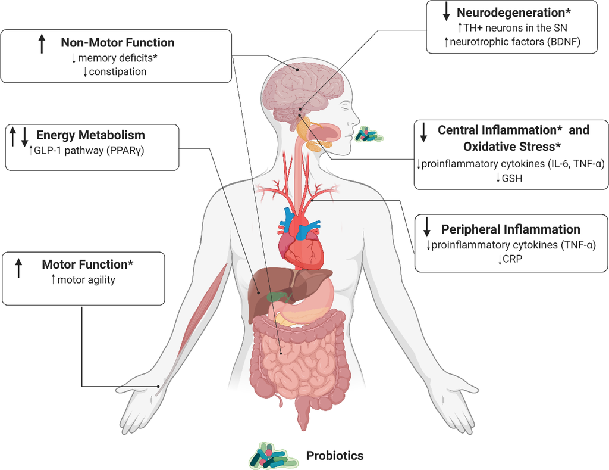

**Fig. 2.** Effects of probiotics in Parkinson’s disease. The figure shows the beneficial effects associated with probiotics supplementation in Parkinson’s disease, which

include modulation of energy metabolism, reduction of peripheral and central inflammation as well as oxidative stress, reduction of neurodegeneration, and increase

motor and non-motor function. Effects demonstrated in preclinical studies only are marked by a star (*) and thus translational research is needed to confirm this basic

scientific result. Abbreviations: BDNF, brain-derived neurotrophic factor; CRP, C-reactive protein; GFAP, glial fibrillary acid protein; GLP-1, glucagon-like peptide 1;

GSH, glutathione; Iba1, ionized calcium-binding adaptor molecule 1; IL-6, interleukin 6; PPARγ, peroxisome proliferator-activated receptor gamma; SN, substantia

nigra; TH+, tyrosine hydroxylase positive; TNF-α, tumour necrosis factor-alpha.

*V. Leta et al.*

*Brain Behavior and Immunity 98 (2021) 59–73*

71

neuroprotective properties in preclinical studies of PD (Fig. 2). This was

observed across a variety of studies, irrespective of the model, treatment

duration or probiotic strain employed (Alipour Nosrani et al., 2020;

Castelli et al., 2020; Goya et al., 2020; Hsieh et al., 2020; Liao et al.,

2020; Marsova et al., 2020; Perez Vis˜nuk et al., 2020; Srivastav et al.,

2019; Sun et al., 2020). The increase in the levels of dopaminergic

neurons in the substantia nigra supports the ability of these bacteria to

exert a central neuroprotective action. Indeed, this may be the result of a

concomitant inhibition of pro-inflammatory markers, including the

production of pro-inflammatory cytokines (Magistrelli et al., 2019;

Perez Vis˜nuk et al., 2020) and oxidant molecules (Liao et al., 2020;

Magistrelli et al., 2019), and activation of neurotrophic factors,

including BDNF and NGF (Silva et al., 2020; Yang et al., 2020), which

exert neurogenic properties and contribute to the maintenance of brain

plasticity.

The majority of the preclinical studies reviewed here also suggest

that probiotics treatment can prevent the reduction in motor agility

(Fig. 2), despite the probiotic strain, the animal model of PD or duration

of treatment employed (Alipour Nosrani et al., 2020; Castelli et al.,

2020; Goya et al., 2020; Hsieh et al., 2020; Liao et al., 2020; Marsova

et al., 2020; Perez Vis˜nuk et al., 2020; Srivastav et al., 2019; Sun et al.,

2020). The beneficial effect of probiotics on motor function can be

explained by the prevented loss of dopaminergic neurons in the sub-

stantia nigra observed after the bacterial supplementation (Alipour

Nosrani et al., 2020; Castelli et al., 2020; Hsieh et al., 2020; Liao et al.,

2020; Marsova et al., 2020; Perez Vis˜nuk et al., 2020; Srivastav et al.,

2019). In humans, only one study has tested the effects of probiotics on

motor function upon treatment with a mixture of bacteria belonging to

*Firmicutes* or *Actinobacteria* phylum and showed a significant improve-

ment in overall PD symptomatology, including tremor, bradykinesia,

rigidity, and gait dysfunction (Tamtaji et al., 2019). While this approach

is promising, it needs to be replicated in larger placebo-controlled trials,

specifically looking at the motor aspects of PD.

Concerning non-motor symptoms, findings suggest that treatment

with probiotics may prevent cognitive-related deficits in a PD model in

rodents (Alipour Nosrani et al., 2020; Xie and Prasad, 2020) (Fig. 2).

These preclinical results are consistent with findings from one clinical

study, where probiotics supplementation led to an improvement in

overall PD symptomatology, including cognitive impairments (Tamtaji

et al., 2019). Several mechanisms of action can be implicated in the

beneficial effects of probiotics on cognitive impairments in PD, specif-

ically enhanced levels of neurotrophic factors (Castelli et al., 2020; Liao

et al., 2020; Srivastav et al., 2019), reduced loss of dopaminergic neu-

Hsieh et al., 2020; Liao et al., 2020; Marsova et al., 2020; Perez Vis˜nuk

et al., 2020; Srivastav et al., 2019; Sun et al., 2020), as well as improved

glucose tolerance and insulin sensitivity (Borzabadi et al., 2018; Castelli

et al., 2020; Sun et al., 2020; Tamtaji et al., 2019), all of which are key

mechanisms involved in the pathophysiology of cognitive dysfunction in

PD (Aarsland et al., 2017).

In addition to cognitive impairments, another non-motor aspect

assessed in the clinical studies was constipation (Fig. 2), where findings

consistently showed that probiotics can improve constipation-related

features, such as abdominal bloating, pain and stool consistency (Cas-

sani et al., 2011; Georgescu et al., 2016; Tan et al., 2020). This is not

surprising, considering the ability of probiotics to modify the intestinal

luminal environment, ultimately regulating intestinal motility and

secretion (Dimidi et al., 2017). Indeed, probiotics have been recently

recommended by the Movement Disorders Society Evidence-Based

Medicine Committee as a clinically useful therapeutic option for the

treatment of constipation in PD (Barichella et al., 2016; Seppi et al.,

2019). However, while a relative amount of evidence has been gener-

ated so far on the efficacy of probiotics in improving constipation

(Dimidi et al., 2014), the exact underlying mechanisms involved in these

beneficial effects are still to be identified and therefore require addi-

tional investigations. Furthermore, considering the ability of probiotics

to improve abdominal pain and alter peripheral and central mechanisms

involved in pain modulation in PD (Guo et al., 2019), the latter might

represent a novel future research area to explore from both preclinical

and clinical perspectives.

Limitations of this systematic review include the paucity of data

available in the clinical setting, which reflects the novelty of the topic.

Nevertheless, we believe our review is meaningful as it provides a sys-

tematic summary of the currently available evidence and highlights

research gaps to be considered for future translational research. In

addition, we acknowledge the mixed quality of the sources of reference

material and, thus, further high-quality studies with rigorous method-

ology are needed. Other limitations include the use of different strains of

probiotics and different outcome measures across the preclinical and

clinical studies, which makes it challenging to draw a firm conclusion on

the relationship between individual strains of bacteria and specific ef-

fects. The latter, together with the well-known intrinsic challenges in

translating research findings from animal model to humans, can

partially explain some of the inconsistencies found among preclinical

and clinical studies. It is also worth noting that although some evidence

seems to suggest increased levels of *Lactobacillaceae* (usually considered

to be probiotic strains) in faecal samples from patients with PD when

compared to healthy controls, findings are still equivocal rather than

conclusive. Should the increased levels of *Lactobacillaceae* be confirmed

as a biosignature of PD, the underlying mechanisms would need to be

elucidated and it may be argued that this might represent a compensa-

tory mechanism reactive to a proinflammatory intestinal environment

and provide the rational for probiotics to become an effective anti-

inflammatory therapeutic option.

In conclusion, this is the first systematic review that highlights the

potential beneficial effect of probiotics on metabolism, inflammation,

neurogenesis and clinical aspects of PD across both preclinical and

clinical studies. Despite the increasing evidence outlined in our review,

which supports the beneficial effects of probiotic interventions in PD,

further investigations are needed, especially in clinical contexts. Future

research should aim at validating preclinical findings in larger, longi-

tudinal and more controlled clinical studies, to identify the best thera-

peutic strategy (type of probiotic strain, concentration, treatment

duration) for patients with PD.

**Declaration of Competing Interest**

VL has received grants from BRC, Parkinson’s UK, a travel and

congress grant from Bial UK Ltd, speaker-related activities fees from

Britannia pharmaceuticals, Bial UK, and consultancy fees from Invisio

Pharmaceuticals, outside the submitted work. KRC has received hono-

raria for Advisory board from AbbVie, UCB, GKC, Bial, Cynapsus,

Novartis, Lobsor, Stada, Medtronic, Zambon, Profile, Sunovion, Roche,

Theravance, Scion, Britannia; honoraria for lectures from AbbVie, Bri-

tannia, UCB, Mundipharma, Zambon, Novartis, Boeringer Ingelheim;

Grants (Investigator Initiated) from Britannia Pharmaceuticals, AbbVie,

UCB, GKC, Bial; Academic grants from EU, IMI EU, Horizon 2020, Par-

kinson’s UK, NIHR, PDNMG, EU (Horizon 2020), Kirby Laing Founda-

tion, NPF, MRC, Wellcome Trust, outside the submitted work. OM has

nothing to declare. AB and CMP are funded by the UK Medical Research

Council (grants MR/L014815/1, MR/J002739/1 and MR/N029488/1),

the European Commission Horizon 2020 (grant SC1-BHC-01-2019) and

the National Institute for Health Research (NIHR) Biomedical Research

Centre at South London and Maudsley NHS Foundation Trust and King’s

College London; they have also received research funding from Johnson

& Johnson for research on depression and inflammation, but this paper

is independent from this funding. In addition, CMP is funded by the

Wellcome Trust strategy award to the Neuroimmunology of Mood Dis-

orders and Alzheimer’s Disease (NIMA) Consortium (104025), which is

also funded by Janssen, GlaxoSmithKline, Lundbeck and Pfizer, but,

again, this paper is independent from this funding.

*V. Leta et al.*

*Brain Behavior and Immunity 98 (2021) 59–73*

72

*Acknowledgement*

The authors acknowledge the support of the Movement Disorder

Society Non-Motor PD Study Group, the National Institute for Health

Research (NIHR) London South Clinical Research Network and the NIHR

Biomedical Research Centre. This article represents independent

collaborative research part-funded by the NIHR Biomedical Research

Centre at South London and Maudsley NHS Foundation Trust and King’s

College London. The views expressed are those of the author(s) and not

necessarily those of the NHS, the NIHR, or the Department of Health.

Fig. 1 was created using Lucidchart.com. Fig. 2 was created using Bio-

Render.com.

*Funding*

This research did not receive any specific grant from funding

agencies in the public, commercial, or not-for-profit sectors.

**Appendix A. Supplementary data**

Supplementary data to this article can be found online at https://doi.

org/10.1016/j.bbi.2021.07.026.

**References**

Aarsland, D., Creese, B., Politis, M., Chaudhuri, K.R., ffytche, D.H., Weintraub, D.,

Ballard, C., 2017. Cognitive decline in Parkinson disease. Nat. Rev. Neurol. 13 (4),

217–231.

Alecu, I., Bennett, S.A.L., 2019. Dysregulated lipid metabolism and its role in

α-synucleinopathy in Parkinson’s Disease. Front. Neurosci. 13, 328.

Alipour Nosrani, E., Tamtaji, O.R., Alibolandi, Z., Sarkar, P., Ghazanfari, M., Azami

Tameh, A., Taghizadeh, M., Banikazemi, Z., Hadavi, R., Naderi Taheri, M., 2020.

Neuroprotective effects of probiotics bacteria on animal model of Parkinson’s

disease induced by 6-hydroxydopamine: a behavioral, biochemical, and histological

study. J. Immunoassay Immunochem. 1–15.

Athauda, D., Foltynie, T., 2016. Insulin resistance and Parkinson’s disease: a new target

for disease modification? Prog. Neurobiol. 145–146, 98–120.

Athauda, D., Wyse, R., Brundin, P., Foltynie, T., 2017. Is exenatide a treatment for

Parkinson’s Disease? J. Parkinson’s Dis. 7, 451–458.

Barcelo, A., Claustre, J., Moro, F., Chayvialle, J.A., Cuber, J.C., Plaisanci´e, P., 2000.

Mucin secretion is modulated by luminal factors in the isolated vascularly perfused

rat colon. Gut 46, 218–224.

Barichella, M., Pacchetti, C., Bolliri, C., Cassani, E., Iorio, L., Pusani, C., Pinelli, G.,

Privitera, G., Cesari, I., Faierman, S.A., Caccialanza, R., Pezzoli, G., Cereda, E., 2016.

Probiotics and prebiotic fiber for constipation associated with Parkinson disease: an

RCT. Neurology. 87 (12), 1274–1280.

Bermúdez-Humar´an, L.G., Salinas, E., Ortiz, G.G., Ramirez-Jirano, L.J., Morales, J.A.,

Bitzer-Quintero, O.K., 2019. From probiotics to psychobiotics: live beneficial

bacteria which act on the brain-gut axis. Nutrients. 11 (4), 890.

Boertien, J.M., Pereira, P.A.B., Aho, V.T.E., Scheperjans, F., van Laar, T., 2019.

Increasing comparability and utility of gut microbiome studies in Parkinson’s

disease: a systematic review. J. Parkinson’s Dis. 9 (s2), S297–S312.

Borsini, A., Alboni, S., Horowitz, M.A., Tojo, L.M., Cannazza, G., Su, K.P., Pariante, C.M.,

Zunszain, P.A., 2017. Rescue of IL-1beta-induced reduction of human neurogenesis

by omega-3 fatty acids and antidepressants. Brain Behav. Immun. 65, 230–238.

Borsini, A., A. Cattaneo, C. Malpighi, S. Thuret, N.A. Harrison, M.R.C.I. Consortium, P.A.

Zunszain, C.M. Pariante. 2018. Interferon-alpha reduces human hippocampal

neurogenesis and increases apoptosis via activation of distinct STAT1-dependent

mechanisms. Int. J. Neuropsychopharmacol. 21:187-200.

Borsini, A., Di Benedetto, M.G., Giacobbe, J., Pariante, C.M., 2020. Pro- and anti-

inflammatory properties of interleukin (IL6) in vitro: relevance for major depression

and for human hippocampal neurogenesis. Int. J. Neuropsychopharmacol. 21,

187–200.

Borzabadi, S., Oryan, S., Eidi, A., Aghadavod, E., Daneshvar Kakhaki, R., Tamtaji, O.R.,

Taghizadeh, M., Asemi, Z., 2018. The effects of probiotic supplementation on gene

expression related to inflammation, insulin and lipid in patients with Parkinson’s

Disease: a randomized, double-blind PlaceboControlled Trial. Arch. Iranian Med. 21,

289–295.

Cassani, E., Privitera, G., Pezzoli, G., Pusani, C., Madio, C., Iorio, L., Barichella, M., 2011.

Use of probiotics for the treatment of constipation in Parkinson’s disease patients.

Minerva Gastroenterol. Dietol. 57, 117–121.

Castelli, V., d’Angelo, M., Lombardi, F., Alfonsetti, M., Antonosante, A., Catanesi, M.,

Benedetti, E., Palumbo, P., Cifone, M.G., Giordano, A., Desideri, G., Cimini, A., 2020.

Effects of the probiotic formulation SLAB51 in in vitro and in vivo Parkinson’s

disease models. Aging 12 (5), 4641–4659.

d’Angelo, M., Castelli, V., Catanesi, M., Antonosante, A., Dominguez-Benot, R.,

Ippoliti, R., Benedetti, E., Cimini, A., 2019. PPARγ and cognitive performance. Int. J.

Mol. Sci. 20 (20), 5068. https://doi.org/10.3390/ijms20205068.

Dimidi, E., S. Christodoulides, K.C. Fragkos, S.M. Scott, and K. Whelan. 2014. The effect

of probiotics on functional constipation in adults: a systematic review and meta-

analysis of randomized controlled trials. Am. J Clin. Nutrit. 100:1075–1084.

Dimidi, E., Christodoulides, S., Scott, S.M., Whelan, K., 2017. Mechanisms of action of

probiotics and the gastrointestinal microbiota on gut motility and constipation. Adv

Nutr. 8 (3), 484–494.

Dunn, L., Allen, G.FG., Mamais, A., Ling, H., Li, A., Duberley, K.E., Hargreaves, I.P.,

Pope, S., Holton, J.L., Lees, A., Heales, S.J., Bandopadhyay, R., 2014. Dysregulation

of glucose metabolism is an early event in sporadic Parkinson’s disease. Neurobiol.

Aging 35 (5), 1111–1115.

Dwyer, Z., Chaiquin, M., Landrigan, J., Ayoub, K., Shail, P., Rocha, J., Childers, C.L.,

Storey, K.B., Philpott, D.J., Sun, H., Hayley, S., 2021. The impact of dextran sodium

sulphate and probiotic pre-treatment in a murine model of Parkinson’s disease.

J. Neuroinflamm. 18, 1–15.

Georgescu, D., Ancusa, O.E., Georgescu, L.A., Ionita, I., Reisz, D., 2016. Nonmotor

gastrointestinal disorders in older patients with Parkinson’s disease: is there hope?

Clin. Interv. Aging 11, 1601–1608.

Goya, M.E., Xue, F., Sampedro-Torres-Quevedo, C., Arnaouteli, S., Riquelme-

Dominguez, L., Romanowski, A., Brydon, J., Ball, K.L., Stanley-Wall, N.R.,

Doitsidou, M., 2020. Probiotic Bacillus subtilis protects against α-synuclein

aggregation in C. elegans. Cell reports. 30 (2), 367–380.e7.

Griffin, W.S., Liu, L., Li, Y., Mrak, R.E., Barger, S.W., 2006. Interleukin-1 mediates

Alzheimer and Lewy body pathologies. J. Neuroinflamm. 3, 1–9.

Guo, R., Chen, L.-H., Xing, C., Liu, T., 2019. Pain regulation by gut microbiota: molecular

mechanisms and therapeutic potential. Br. J. Anaesth. 123 (5), 637–654.

Heintz-Buschart, A., Pandey, U., Wicke, T., Sixel-D¨oring, F., Janzen, A., Sittig-

Wiegand, E., Trenkwalder, C., Oertel, W.H., Mollenhauer, B., Wilmes, P., 2018. The

nasal and gut microbiome in Parkinson’s disease and idiopathic rapid eye movement

sleep behavior disorder. Movem. Disorders. 33 (1), 88–98.

Hollister, E.B., Gao, C., Versalovic, J., 2014. Compositional and functional features of the

gastrointestinal microbiome and their effects on human health. Gastroenterology

146 (6), 1449–1458.

Hooijmans, C.R., Rovers, M.M., de Vries, R.B., Leenaars, M., Ritskes-Hoitinga, M.,

Langendam, M.W., 2014. SYRCLE’s risk of bias tool for animal studies. BMC Med.

Res. Method. 14, 1–9.

Houser, M.C., Tansey, M.G., 2017. The gut-brain axis: is intestinal inflammation a silent

driver of Parkinson’s disease pathogenesis? npj Parkinson’s Dis. 3, 1–9.

Hsieh, T.-H., Kuo, C.-W., Hsieh, K.-H., Shieh, M.-J., Peng, C.-W., Chen, Y.-C., Chang, Y.-

L., Huang, Y.-Z., Chen, C.-C., Chang, P.-K., Chen, K.-Y., Chen, H.-Y., 2020. Probiotics

alleviate the progressive deterioration of motor functions in a mouse model of

Parkinson’s Disease. Brain Sci. 10 (4), 206.

Hughes, A.J., Daniel, S.E., Kilford, L., Lees, A.J., 1992. Accuracy of clinical diagnosis of

idiopathic Parkinson’s disease: a clinico-pathological study of 100 cases. J. Neurol.

Neurosurg. Psychiatry 55 (3), 181–184.

Kalia, L.V., Lang, A.E., 2015. Parkinson’s disease. Lancet (London, England). 386 (9996),

896–912.

Kelly, L.P., Carvey, P.M., Keshavarzian, A., Shannon, K.M., Shaikh, M., Bakay, R.A.E.,

Kordower, J.H., 2014. Progression of intestinal permeability changes and alpha-

synuclein expression in a mouse model of Parkinson’s disease. Movem. Dis. 29 (8),

999–1009.

Keshavarzian, A., Engen, P., Bonvegna, S., Cilia, R., 2020. The gut microbiome in

Parkinson’s disease: A culprit or a bystander? Prog. Brain Res. 252, 357–450.

Klingelhoefer, L., Reichmann, H., 2015. Pathogenesis of Parkinson disease–the gut-brain

axis and environmental factors. Nat. Rev. Neurol. 11 (11), 625–636.

Konnova, E.A., and M. Swanberg. 2018. Animal Models of Parkinson’s Disease. In

Parkinson’s Disease: Pathogenesis and Clinical Aspects. T.B. Stoker and J.C.

Greenland, editors. Codon Publications. Copyright: The Authors., Brisbane (AU).

Leta, V., Urso, D., Batzu, L., Weintraub, D., Titova, N., Aarsland, D., Martinez-Martin, P.,

Borghammer, P., van Wamelen, D.J., Yousaf, T., Rizos, A., Rodriguez-Blazquez, C.,

Chung-Faye, G., Ray Chaudhuri, K., 2021. Constipation is Associated with

Development of Cognitive Impairment in de novo Parkinson’s Disease: A

Longitudinal Analysis of Two International Cohorts. J Parkinsons Dis. 11 (3),

1209–1219. https://doi.org/10.3233/JPD-212570.

Liao, J.-F., Cheng, Y.-F., You, S.-T., Kuo, W.-C., Huang, C.-W., Chiou, J.-J., Hsu, C.-C.,

Hsieh-Li, H.-M., Wang, S., Tsai, Y.-C., 2020. Lactobacillus plantarum PS128

alleviates neurodegenerative progression in 1-methyl-4-phenyl-1,2,3,6-tetrahydro-

pyridine-induced mouse models of Parkinson’s disease. Brain Behav. Immun. 90,

26–46.

Liberati, A., Altman, D.G., Tetzlaff, J., Mulrow, C., Gøtzsche, P.C., Ioannidis, J.P.A.,

Clarke, M., Devereaux, P.J., Kleijnen, J., Moher, D., 2009. The PRISMA statement for

reporting systematic reviews and meta-analyses of studies that evaluate health care

interventions: explanation and elaboration. J. Clin. Epidemiol. 62 (10), e1–e34.

Lim, J., Bang, Y., Choi, H.J., 2018. Abnormal hippocampal neurogenesis in Parkinson’s

disease: relevance to a new therapeutic target for depression with Parkinson’s

disease. Arch Pharm Res. 41 (10), 943–954.

Magistrelli, L., Amoruso, A., Mogna, L., Graziano, T., Cantello, R., Pane, M., Comi, C.,

2019. Probiotics may have beneficial effects in Parkinson’s disease: in vitro

evidence. Front. Immunol. 10, 969.

Markowiak, P., <sup>´</sup>Sli˙zewska, K., 2017. Effects of probiotics, prebiotics, and synbiotics on

human health. Nutrients 9, 1021.

Marsova, M., Poluektova, E., Odorskaya, M., Ambaryan, A., Revishchin, A., Pavlova, G.,

Danilenko, V., 2020. Protective effects of Lactobacillus fermentum U-21 against

paraquat-induced oxidative stress in Caenorhabditis elegans and mouse models.

World J. Microbiol. Biotechnol. 36, 1–10.

Metta, V., Leta, V., Mrudula, K.R., Prashanth, L.K., Goyal, V., Borgohain, R., Chung-

Faye, G., Chaudhuri, K.R., 2021. Gastrointestinal dysfunction in Parkinson’s disease:

*V. Leta et al.*

*Brain Behavior and Immunity 98 (2021) 59–73*

73

molecular pathology and implications of gut microbiome, probiotics, and fecal

microbiota transplantation. J. Neurol. 1–10.

Mohammadi, G., Dargahi, L., Peymani, A., Mirzanejad, Y., Alizadeh, S.A., Naserpour, T.,

Nassiri-Asl, M., 2019. The effects of probiotic formulation pretreatment

(Lactobacillus helveticus R0052 and Bifidobacterium longum R0175) on a

Lipopolysaccharide Rat Model. J. Am. Coll. Nutr. 38 (3), 209–217.

Moher, D., Liberati, A., Tetzlaff, J., Altman, D.G., 2009. Preferred reporting items for

systematic reviews and meta-analyses: the PRISMA statement. PLoS Med. 6 (7),

e1000097.

Morais, L.H., Schreiber, H.L., Mazmanian, S.K., 2021. The gut microbiota-brain axis in

behaviour and brain disorders. Nat Rev Microbiol. 19 (4), 241–255.

Nishiwaki, H., Ito, M., Ishida, T., Hamaguchi, T., Maeda, T., Kashihara, K., Tsuboi, Y.,

Ueyama, J., Shimamura, T., Mori, H., Kurokawa, K., Katsuno, M., Hirayama, M.,

Ohno, K., 2020. Meta-analysis of gut dysbiosis in Parkinson’s disease. Movem.

Disord. 35, 1626–1635.

Perez Vis˜nuk, D., G. Savoy de Giori, J.G. LeBlanc, and A. de Moreno de LeBlanc. 2020.

Neuroprotective effects associated with immune modulation by selected lactic acid

bacteria in a Parkinson’s disease model. Nutrition (Burbank, Los Angeles County,

Calif.). 79:110995.

Postuma, R.B., Berg, D., Stern, M., Poewe, W., Olanow, C.W., Oertel, W., Obeso, J.,

Marek, K., Litvan, I., Lang, A.E., Halliday, G., Goetz, C.G., Gasser, T., Dubois, B.,

Chan, P., Bloem, B.R., Adler, C.H., Deuschl, Günther, 2015. MDS clinical diagnostic

criteria for Parkinson’s disease. Movem. Disorders 30 (12), 1591–1601.

Purton, T., Staskova, L., Lane, M.M., Dawson, S.L., West, M., Firth, J., Clarke, G.,

Cryan, J.F., Berk, M., O’Neil, A., Dean, O., Hadi, A., Honan, C., Marx, W., 2021.

Prebiotic and probiotic supplementation and the tryptophan-kynurenine pathway: a

systematic review and meta analysis. Neurosci. Biobehav. Rev. 123, 1–13.

Rocha, N.P., de Miranda, A.S., Teixeira, A.L., 2015. Insights into neuroinflammation in

Parkinson’s disease: from biomarkers to anti-inflammatory based therapies. Biomed

Res. Int. 2015, 1–12.

Romano, S., G.M. Savva, J.R. Bedarf, I.G. Charles, F. Hildebrand, and A. Narbad. 2020.

Meta-analysis of the gut microbiome of Parkinson’s disease patients suggests

alterations linked to intestinal inflammation. medRxiv: 1397.

Schapira, A.H.V., Chaudhuri, K.R., Jenner, P., 2017. Non-motor features of Parkinson

disease. Nat. Rev. Neurosci. 18 (7), 435–450.

Scheperjans, F., Aho, V., Pereira, P.A.B., Koskinen, K., Paulin, L., Pekkonen, E.,

Haapaniemi, E., Kaakkola, S., Eerola-Rautio, J., Pohja, M., Kinnunen, E., Murros, K.,

Auvinen, P., 2015. Gut microbiota are related to Parkinson’s disease and clinical

phenotype. Movem. Dis. 30 (3), 350–358.

Seppi, K., Ray Chaudhuri, K., Coelho, M., Fox, S.H., Katzenschlager, R., Perez Lloret, S.,

Weintraub, D., Sampaio, C., Chahine, L., Hametner, E., Heim, B., Lim, S., Poewe, W.,

Djamshidian-Tehrani, A., 2019. Update on treatments for nonmotor symptoms of

Parkinson’s disease-an evidence-based medicine review. Movem. Disorders 34 (2),

180–198.

Shahbazi, R., Yasavoli-Sharahi, H., Alsadi, N., Ismail, N., Matar, C., 2020. Probiotics in

treatment of viral respiratory infections and neuroinflammatory disorders.

Molecules 25 (21), 4891. https://doi.org/10.3390/molecules25214891.

Shults, C.W., 2006. Lewy bodies. PNAS 103 (6), 1661–1668.

Silva, Y.P., Bernardi, A., Frozza, R.L., 2020. The role of short-chain fatty acids from gut

microbiota in gut-brain communication. Front. Endocrinol. (Lausanne) 11, 25.

Srivastav, S., Neupane, S., Bhurtel, S., Katila, N., Maharjan, S., Choi, H., Hong, J.T.,

Choi, D.-Y., 2019. Probiotics mixture increases butyrate, and subsequently rescues

the nigral dopaminergic neurons from MPTP and rotenone-induced neurotoxicity.

J. Nutrit. Biochem. 69, 73–86.

Sterne, J.A.C., Savovi´c, J., Page, M.J., Elbers, R.G., Blencowe, N.S., Boutron, I., Cates, C.

J., Cheng, H.Y., Corbett, M.S., Eldridge, S.M., Emberson, J.R., Hern´an, M.A.,

Hopewell, S., Hr´objartsson, A., Junqueira, D.R., Jüni, P., Kirkham, J.J., Lasserson, T.,

Li, T., McAleenan, A., Reeves, B.C., Shepperd, S., Shrier, I., Stewart, L.A., Tilling, K.,

White, I.R., Whiting, P.F., Higgins, J.P.T., 2019. RoB 2: a revised tool for assessing

risk of bias in randomised trials. BMJ (Clin. Res. ed.) 366 (l4898).

Sulzer, D., Alcalay, R.N., Garretti, F., Cote, L., Kanter, E., Agin-Liebes, J., Liong, C.,

McMurtrey, C., Hildebrand, W.H., Mao, X., Dawson, V.L., Dawson, T.M., Oseroff, C.,

Pham, J., Sidney, J., Dillon, M.B., Carpenter, C., Weiskopf, D., Phillips, E., Mallal, S.,

Peters, B., Frazier, A., Lindestam Arlehamn, C.S., Sette, A., 2017. T cells from

patients with Parkinson’s disease recognize α-synuclein peptides. Nature 546 (7660),

656–661.

Sun, J., Li, H., Jin, Y., Yu, J., Mao, S., Su, K.P., Ling, Z., Liu, J., 2020. Probiotic

Clostridium butyricum ameliorated motor deficits in a mouse model of Parkinson’s

disease via gut microbiota-GLP-1 pathway. Brain Behav. Immun. 91, 703–715.

Syed, Y.Y., McCormack, P.L., 2015. Exenatide extended-release: an updated review of its

use in type 2 diabetes mellitus. Drugs 75 (10), 1141–1152.

Tamtaji, O.R., Taghizadeh, M., Daneshvar Kakhaki, R., Kouchaki, E., Bahmani, F.,

Borzabadi, S., Oryan, S., Mafi, A., Asemi, Z., 2019. Clinical and metabolic response

to probiotic administration in people with Parkinson’s disease: a randomized,

double-blind, placebo-controlled trial. Clin. Nutrit. 38 (3), 1031–1035.

Tan, A.H., Lim, S.Y., Chong, K.K., Azhan, A.M.M.A., Hor, J.W., Lim, J.L., Low, S.C.,

Chong, C.W., Mahadeva, S., Lang, A.E., 2020. Probiotics for constipation in

Parkinson’s disease: a randomized placebo-controlled study. Neurology 5, 772–782.

Unger, M.M., Spiegel, J¨org, Dillmann, K.-U., Grundmann, D., Philippeit, H., Bürmann, J.,

Faßbender, K., Schwiertz, A., Sch¨afer, K.-H., 2016. Short chain fatty acids and gut

microbiota differ between patients with Parkinson’s disease and age-matched

controls. Parkinsonism & Related Disorders 32, 66–72.

Venkatesan, D., Iyer, M., Narayanasamy, A., Siva, K., Vellingiri, B., 2020. Kynurenine

pathway in Parkinson’s disease-An update. Neurol. Sci. 21, 100270. https://doi.org/

10.1016/j.ensci.2020.100270.

Wallen, Z.D., Appah, M., Dean, M.N., Sesler, C.L., Factor, S.A., Molho, E., Zabetian, C.P.,

Standaert, D.G., Payami, H., 2020. Characterizing dysbiosis of gut microbiome in PD:

evidence for overabundance of opportunistic pathogens. npj Parkinson’s Dis. 6,

11–12.

Xie, C., Prasad, A.A., 2020. Probiotics treatment improves hippocampal dependent

cognition in a rodent model of Parkinson’s Disease. Microorganisms. 8 (11), 1661.

https://doi.org/10.3390/microorganisms8111661.

Xin, J., D. Zeng, H. Wang, N. Sun, A. Khalique, Y. Zhao, L. Wu, K. Pan, B. Jing, and X. Ni.

2020. Lactobacillus johnsonii BS15 improves intestinal environment against

fluoride-induced memory impairment in mice-a study based on the gut-brain axis

hypothesis. PeerJ. 8:1012.

Yang, L.L., Millischer, V., Rodin, S., MacFabe, D.F., Villaescusa, J.C., Lavebratt, C., 2020.

Enteric short-chain fatty acids promote proliferation of human neural progenitor

cells. J. Neurochem. 154 (6), 635–646.

*V. Leta et al.*